# Codebook

Here, we’re just setting a few options.

```r
knitr::opts_chunk$set(
  warning = FALSE, # show warnings during codebook generation
  message = FALSE, # show messages during codebook generation
  error = TRUE, # do not interrupt codebook generation in case of errors,
                # usually better for debugging
  echo = TRUE  # show R code
)
ggplot2::theme_set(ggplot2::theme_bw())
```

Now, we’re preparing our data for the codebook.

```r
library(codebook)
library(formr)
library(ufs)
library(GGally)



############################################################################## #
###   THESE ARE THE ONLY three LINES OF CODE THAT I NEED TO ENTER   ########## #
############################################################################## #

# formr_store_keys("juergen") # save my login credentials (do just once)
formr_connect(keyring = "juergen") # retreive credentials and login to formr

codebook_data <- formr_results("utrecht_od") %>% # pulls survey results
                                                 # also aggregates items with
                                                 # the same name and continuous
                                                 # numbers at the end

                   subset(select = -c(session_id, # and I'm just gonna delete
                                      study_id,   # these formr variables
                                      iteration,
                                      quan_qual_other))


############################################################################## #
###   I DIDN'T CHANGE ANYTHING AFTER THIS                           ########## #
############################################################################## #




# to import an SPSS file from the same folder uncomment and edit the line below
# codebook_data <- rio::import("mydata.sav")
# for Stata
# codebook_data <- rio::import("mydata.dta")
# for CSV
# codebook_data <- rio::import("mydata.csv")

# omit the following lines, if your missing values are already properly labelled
codebook_data <- detect_missing(codebook_data,
    only_labelled = TRUE, # only labelled values are autodetected as
                                   # missing
    negative_values_are_missing = FALSE, # negative values are missing values
    ninety_nine_problems = TRUE,   # 99/999 are missing values, if they
                                   # are more than 5 MAD from the median
    )

# If you are not using formr, the codebook package needs to guess which items
# form a scale. The following line finds item aggregates with names like this:
# scale = scale_1 + scale_2R + scale_3R
# identifying these aggregates allows the codebook function to
# automatically compute reliabilities.
# However, it will not reverse items automatically.
codebook_data <- detect_scales(codebook_data)
```

Create codebook

```r
codebook(codebook_data)
```

### Metadata

#### Description

**Dataset name**: codebook_data

The dataset has N=45 rows and 14 columns. 0 rows have no missing values on any column.

**Metadata for search engines**

- **Date published**: 2024-09-25

| x |
| --- |
| session |
| created |
| modified |
| ended |
| expired |
| fair_1 |
| fair_2 |
| personal |
| consent |
| codebook |
| repo_rdc |
| quan_qual |
| obstacles |
| fair |

### Survey overview

13 completed rows, 14 who entered any information, 31 only viewed the first page. There are 0 expired rows (people who did not finish filling out in the requested time frame). In total, there are 45 rows including unfinished and expired rows.

There were 45 unique participants, of which 13 finished filling out at least one survey.

This survey was not repeated.

The first session started on 2024-09-18 19:32:56, the last session on 2024-09-23 08:35:06.

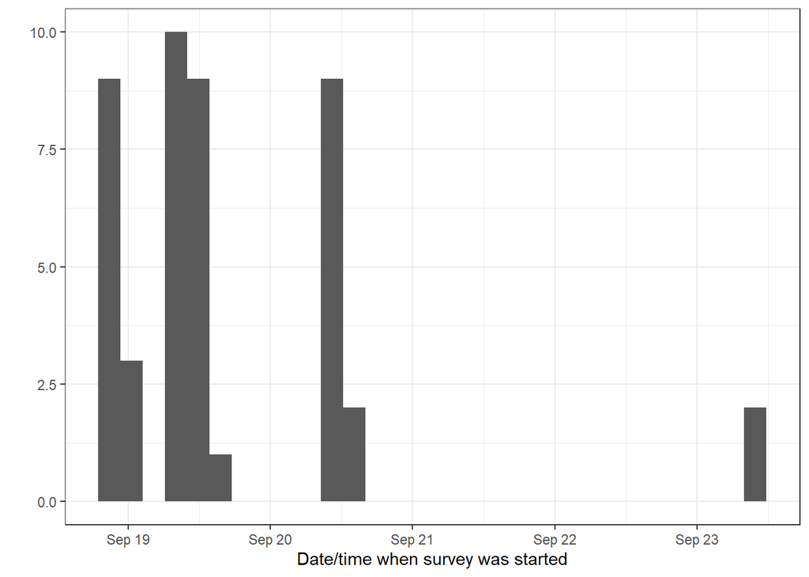

Starting date times

People took on average 3.05 minutes (median 2.5) to answer the survey.

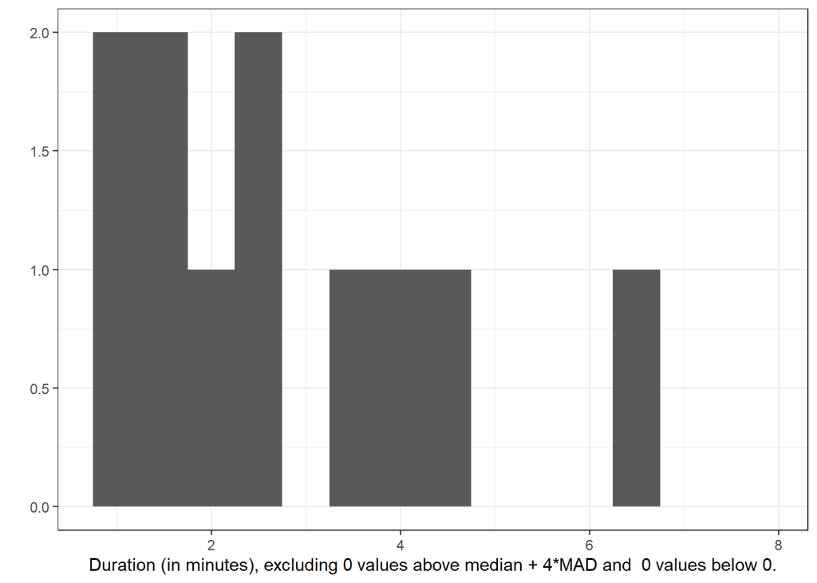

Duration people took for answering the survey

## Variables

### personal

I know how to judge, whether a data set counts as personal data.

#### Distribution

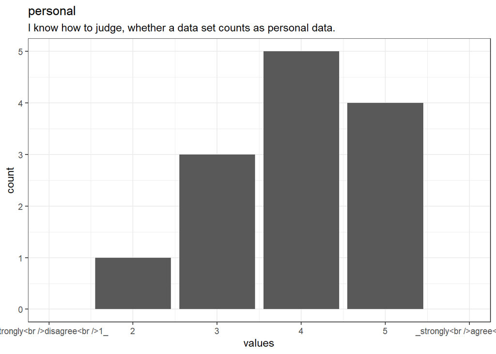

Distribution of values for personal

32 missing values.

#### Summary statistics

| name | label | type | type_options | data_type | optional | showif | value | item_order | block_order | class | n_missing | complete_rate | min | median | max | mean | sd | n_value_labels | hist |
| --- | --- | --- | --- | --- | --- | --- | --- | --- | --- | --- | --- | --- | --- | --- | --- | --- | --- | --- | --- |
| personal | I know how to judge, whether a data set counts as personal data. | mc_button |  | haven_labelled | 0 |  |  | 5 |  | left300 mc_width60 show_value_instead_of_label hide_label | 32 | 0.2888889 | 2 | 4 | 5 | 3.923077 | 0.9540736 | 7 | ▂▁▅▁▁▇▁▆ |

#### Item

Item options

| type | type_options | name | label | optional | class | showif | value | block_order | item_order |
| --- | --- | --- | --- | --- | --- | --- | --- | --- | --- |
| mc_button |  | personal | I know how to judge, whether a data set counts as personal data. | 0 | left300 mc_width60 show_value_instead_of_label hide_label |  |  |  | 5 |

#### Value labels

Response choices

| name | value |
| --- | --- |
| *strongly<br />disagree<br />1* | 1 |
| 2 | 2 |
| 3 | 3 |
| 4 | 4 |
| 5 | 5 |
| *strongly<br />agree<br />6* | 6 |
| Item was never rendered for this user. | NA |

### consent

I know what the informed consent needs to include (not include), so I can share my data.

#### Distribution

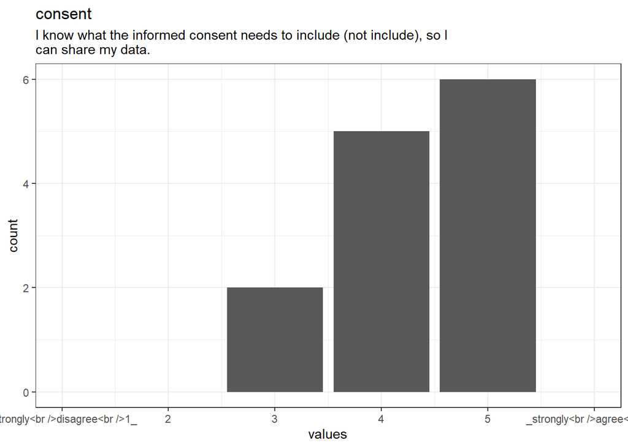

Distribution of values for consent

32 missing values.

#### Summary statistics

| name | label | type | type_options | data_type | optional | showif | value | item_order | block_order | class | n_missing | complete_rate | min | median | max | mean | sd | n_value_labels | hist |
| --- | --- | --- | --- | --- | --- | --- | --- | --- | --- | --- | --- | --- | --- | --- | --- | --- | --- | --- | --- |
| consent | I know what the informed consent needs to include (not include), so I can share my data. | mc_button |  | haven_labelled | 0 |  |  | 6 |  | left300 mc_width60 show_value_instead_of_label hide_label | 32 | 0.2888889 | 3 | 4 | 5 | 4.307692 | 0.7510676 | 7 | ▂▁▁▇▁▁▁▇ |

#### Item

Item options

| type | type_options | name | label | optional | class | showif | value | block_order | item_order |
| --- | --- | --- | --- | --- | --- | --- | --- | --- | --- |
| mc_button |  | consent | I know what the informed consent needs to include (not include), so I can share my data. | 0 | left300 mc_width60 show_value_instead_of_label hide_label |  |  |  | 6 |

#### Value labels

Response choices

| name | value |
| --- | --- |
| *strongly<br />disagree<br />1* | 1 |
| 2 | 2 |
| 3 | 3 |
| 4 | 4 |
| 5 | 5 |
| *strongly<br />agree<br />6* | 6 |
| Item was never rendered for this user. | NA |

### codebook

I know how to create a codebook to accompany my data for sharing purposes.

#### Distribution

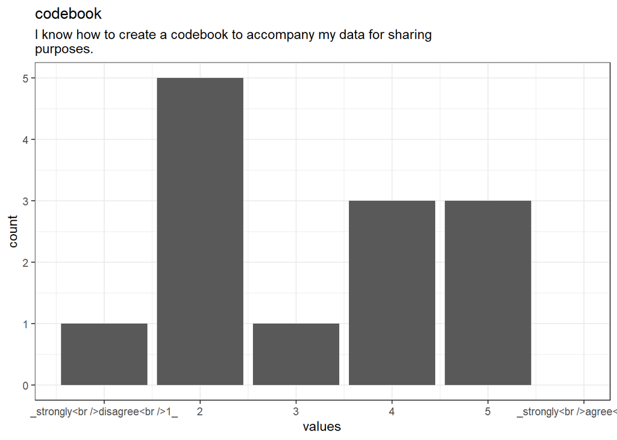

Distribution of values for codebook

32 missing values.

#### Summary statistics

| name | label | type | type_options | data_type | optional | showif | value | item_order | block_order | class | n_missing | complete_rate | min | median | max | mean | sd | n_value_labels | hist |
| --- | --- | --- | --- | --- | --- | --- | --- | --- | --- | --- | --- | --- | --- | --- | --- | --- | --- | --- | --- |
| codebook | I know how to create a codebook to accompany my data for sharing purposes. | mc_button |  | haven_labelled | 0 |  |  | 7 |  | left300 mc_width60 show_value_instead_of_label hide_label | 32 | 0.2888889 | 1 | 3 | 5 | 3.153846 | 1.405119 | 7 | ▂▇▁▂▁▅▁▅ |

#### Item

Item options

| type | type_options | name | label | optional | class | showif | value | block_order | item_order |
| --- | --- | --- | --- | --- | --- | --- | --- | --- | --- |
| mc_button |  | codebook | I know how to create a codebook to accompany my data for sharing purposes. | 0 | left300 mc_width60 show_value_instead_of_label hide_label |  |  |  | 7 |

#### Value labels

Response choices

| name | value |
| --- | --- |
| *strongly<br />disagree<br />1* | 1 |
| 2 | 2 |
| 3 | 3 |
| 4 | 4 |
| 5 | 5 |
| *strongly<br />agree<br />6* | 6 |
| Item was never rendered for this user. | NA |

### repo_rdc

I am aware of appropriate repositories and research data centers for sharing data based on different requirements.

#### Distribution

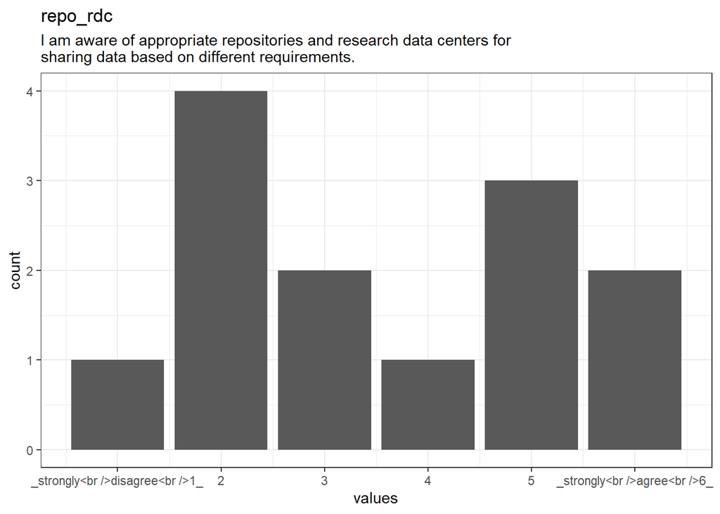

Distribution of values for repo_rdc

32 missing values.

#### Summary statistics

| name | label | type | type_options | data_type | optional | showif | value | item_order | block_order | class | n_missing | complete_rate | min | median | max | mean | sd | n_value_labels | hist |
| --- | --- | --- | --- | --- | --- | --- | --- | --- | --- | --- | --- | --- | --- | --- | --- | --- | --- | --- | --- |
| repo_rdc | I am aware of appropriate repositories and research data centers for sharing data based on different requirements. | mc_button |  | haven_labelled | 0 |  |  | 8 |  | left300 mc_width60 show_value_instead_of_label hide_label | 32 | 0.2888889 | 1 | 3 | 6 | 3.538461 | 1.713446 | 7 | ▂▇▁▃▂▁▆▃ |

#### Item

Item options

| type | type_options | name | label | optional | class | showif | value | block_order | item_order |
| --- | --- | --- | --- | --- | --- | --- | --- | --- | --- |
| mc_button |  | repo_rdc | I am aware of appropriate repositories and research data centers for sharing data based on different requirements. | 0 | left300 mc_width60 show_value_instead_of_label hide_label |  |  |  | 8 |

#### Value labels

Response choices

| name | value |
| --- | --- |
| *strongly<br />disagree<br />1* | 1 |
| 2 | 2 |
| 3 | 3 |
| 4 | 4 |
| 5 | 5 |
| *strongly<br />agree<br />6* | 6 |
| Item was never rendered for this user. | NA |

### quan_qual

The research data I am working with is primarily

#### Distribution

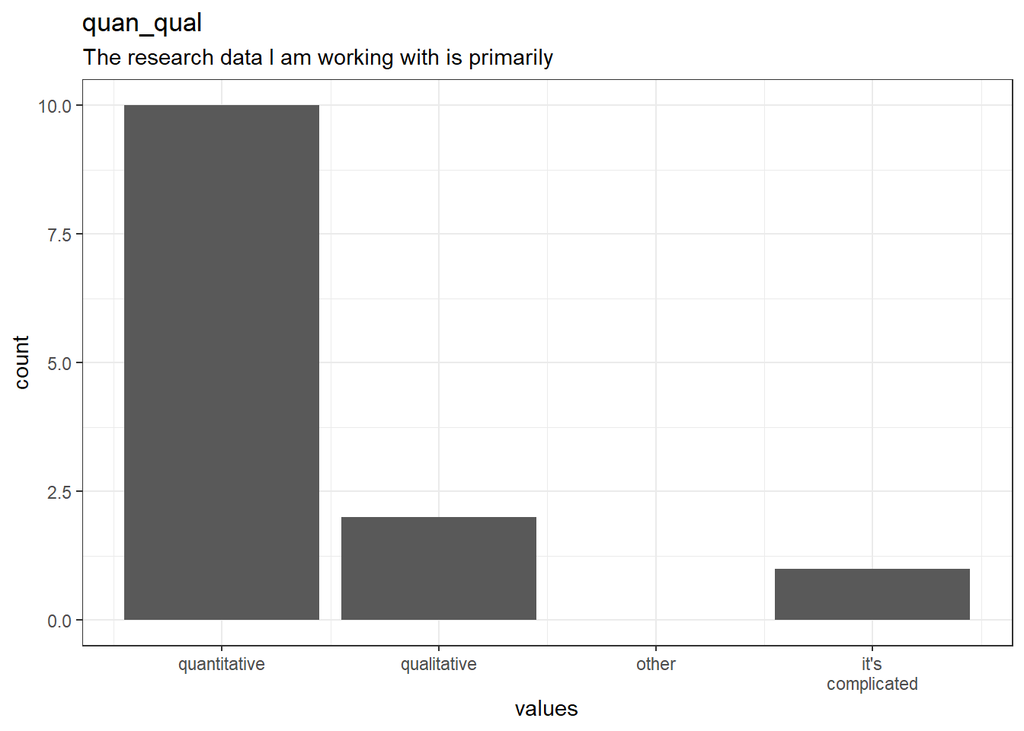

Distribution of values for quan_qual

32 missing values.

#### Summary statistics

| name | label | type | data_type | optional | showif | value | item_order | block_order | class | n_missing | complete_rate | min | median | max | mean | sd | n_value_labels | hist |
| --- | --- | --- | --- | --- | --- | --- | --- | --- | --- | --- | --- | --- | --- | --- | --- | --- | --- | --- |
| quan_qual | The research data I am working with is primarily | mc_button | haven_labelled | 0 |  |  | 9 |  | left300 | 32 | 0.2888889 | 1 | 1 | 4 | 1.384615 | 0.8697185 | 5 | ▇▁▂▁▁▁▁▁ |

#### Item

Item options

| type | name | label | optional | class | showif | value | block_order | item_order |
| --- | --- | --- | --- | --- | --- | --- | --- | --- |
| mc_button | quan_qual | The research data I am working with is primarily | 0 | left300 |  |  |  | 9 |

#### Value labels

Response choices

| name | value |
| --- | --- |
| quantitative | 1 |
| qualitative | 2 |
| other | 3 |
| it’s complicated | 4 |
| Item was never rendered for this user. | NA |

### obstacles

#### Distribution

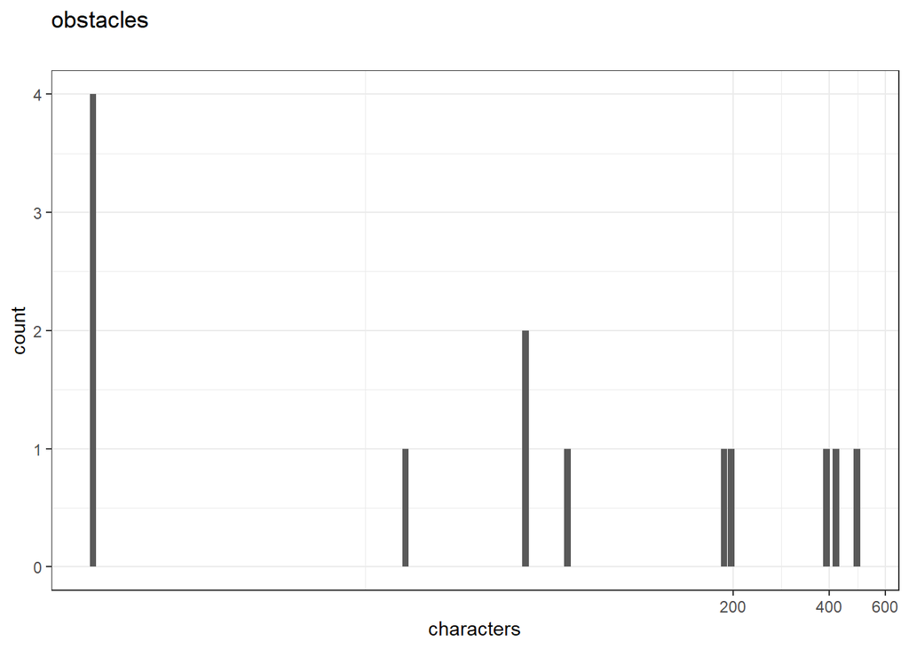

Distribution of values for obstacles

32 missing values.

#### Summary statistics

| name | data_type | n_missing | complete_rate | n_unique | empty | min | max | whitespace | label |
| --- | --- | --- | --- | --- | --- | --- | --- | --- | --- |
| obstacles | character | 32 | 0.2888889 | 12 | 0 | 1 | 489 | 1 | NA |

### Scale: fair

#### Overview

**Missing**: 32.

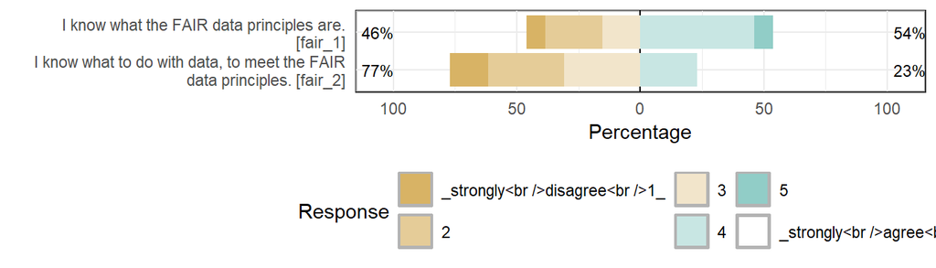

Likert plot of scale fair items

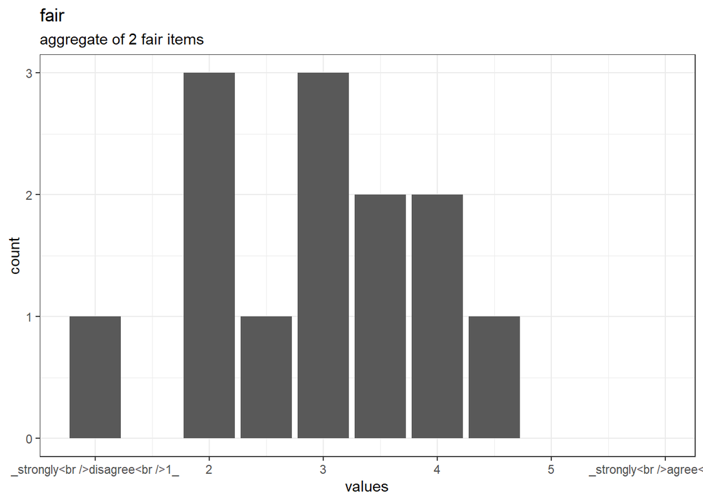

Distribution of scale fair

#### Reliability details

##### Scale structure

###### Information about this scale

| Dataframe: | res$dat |
| --- | --- |
| Items: | fair_1 & fair_2 |
| Observations: | 13 |
| Positive correlations: | 1 |
| Number of correlations: | 1 |
| Percentage positive correlations: | 100 |

###### Estimates assuming interval level

###### Estimates for two-item measures

| Spearman Brown coefficient: | 0.77 |
| --- | --- |
| Coefficient Alpha: | 0.77 |
| Pearson Correlation: | 0.63 |

###### Eigen values

1.627 & 0.373

###### Item descriptives

|  | mean | median | var | sd | IQR | se | min | q1 | q3 | max | skew | kurt | dip | n | NA | valid |
| --- | --- | --- | --- | --- | --- | --- | --- | --- | --- | --- | --- | --- | --- | --- | --- | --- |
| fair_1 | 3.2308 | 4 | 1.359 | 1.1658 | 2 | 0.3233 | 1 | 2 | 5 | 5 | -0.5253 | -0.6758 | 0.1154 | 13 | 0 | 13 |
| fair_2 | 2.6154 | 3 | 1.0897 | 1.0439 | 1 | 0.2895 | 1 | 2 | 4 | 4 | -0.1014 | -0.9891 | 0.1538 | 13 | 0 | 13 |

###### Scattermatrix

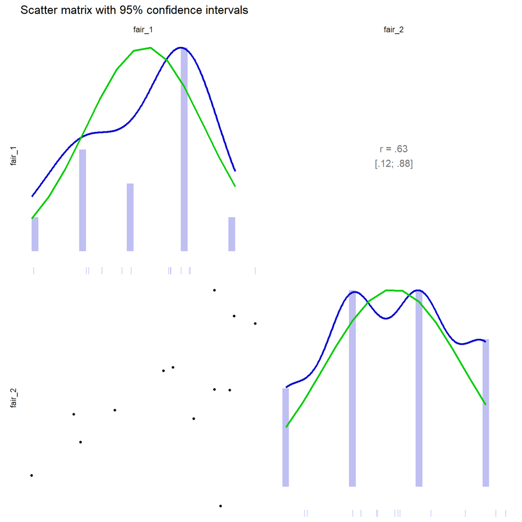

Scatterplot

#### Summary statistics

| name | label | type | type_options | data_type | value_labels | optional | showif | value | item_order | block_order | class | n_missing | complete_rate | min | median | max | mean | sd | n_value_labels | hist |
| --- | --- | --- | --- | --- | --- | --- | --- | --- | --- | --- | --- | --- | --- | --- | --- | --- | --- | --- | --- | --- |
| fair_1 | I know what the FAIR data principles are. | mc_button |  | haven_labelled | 1. *strongly<br />disagree<br />1*, 2. 2, 3. 3, 4. 4, 5. 5, 6. *strongly<br />agree<br />6*, NA. Item was never rendered for this user. | 0 |  |  | 3 |  | left300 mc_width60 show_value_instead_of_label hide_label | 32 | 0.2888889 | 1 | 4 | 5 | 3.230769 | 1.165751 | 7 | ▁▃▁▂▁▇▁▁ |
| fair_2 | I know what to do with data, to meet the FAIR data principles. | mc_button |  | haven_labelled | 1. *strongly<br />disagree<br />1*, 2. 2, 3. 3, 4. 4, 5. 5, 6. *strongly<br />agree<br />6*, NA. Item was never rendered for this user. | 0 |  |  | 4 |  | left300 mc_width60 show_value_instead_of_label hide_label | 32 | 0.2888889 | 1 | 3 | 4 | 2.615385 | 1.043908 | 7 | ▃▁▇▁▁▇▁▆ |

## Missingness report

| description | modified | ended | fair_1 | fair_2 | personal | consent | codebook | repo_rdc | quan_qual | obstacles | fair | expired | var_miss | n_miss |
| --- | --- | --- | --- | --- | --- | --- | --- | --- | --- | --- | --- | --- | --- | --- |
| Missing values per variable | 31 | 32 | 32 | 32 | 32 | 32 | 32 | 32 | 32 | 32 | 32 | 45 | 396 | 396 |
| Missing values in 12 variables | 0 | 0 | 0 | 0 | 0 | 0 | 0 | 0 | 0 | 0 | 0 | 0 | 12 | 31 |
| Missing values in 1 variables | 1 | 1 | 1 | 1 | 1 | 1 | 1 | 1 | 1 | 1 | 1 | 0 | 1 | 13 |
| Missing values in 11 variables | 1 | 0 | 0 | 0 | 0 | 0 | 0 | 0 | 0 | 0 | 0 | 0 | 11 | 1 |

## Codebook table

| name | label | type | type_options | data_type | value_labels | optional | showif | scale_item_names | value | item_order | block_order | class | n_missing | complete_rate | n_unique | empty | count | min | median | max | mean | sd | whitespace | n_value_labels | hist |
| --- | --- | --- | --- | --- | --- | --- | --- | --- | --- | --- | --- | --- | --- | --- | --- | --- | --- | --- | --- | --- | --- | --- | --- | --- | --- |
| session | NA | NA | NA | character | NA | NA | NA | NA | NA | NA | NA | NA | 0 | 1.0000000 | 45 | 0 | NA | 64 | NA | 64 | NA | NA | 0 | NA | NA |
| created | NA | NA | NA | POSIXct | NA | NA | NA | NA | NA | NA | NA | NA | 0 | 1.0000000 | 41 | NA | NA | 2024-09-18 19:32:56 | 2024-09-19 11:43:56 | 2024-09-23 08:35:06 | NA | NA | NA | NA | NA |
| modified | NA | NA | NA | POSIXct | NA | NA | NA | NA | NA | NA | NA | NA | 31 | 0.3111111 | 14 | NA | NA | 2024-09-18 21:45:38 | 2024-09-19 13:46:43.5 | 2024-09-23 08:35:53 | NA | NA | NA | NA | NA |
| ended | NA | NA | NA | POSIXct | NA | NA | NA | NA | NA | NA | NA | NA | 32 | 0.2888889 | 13 | NA | NA | 2024-09-18 21:45:38 | 2024-09-19 12:55:35 | 2024-09-23 08:35:53 | NA | NA | NA | NA | NA |
| expired | NA | NA | NA | logical | NA | NA | NA | NA | NA | NA | NA | NA | 45 | 0.0000000 | NA | NA | : | NA | NA | NA | NaN | NA | NA | NA | NA |
| fair_1 | I know what the FAIR data principles are. | mc_button |  | haven_labelled | 1. *strongly<br />disagree<br />1*, 2. 2, 3. 3, 4. 4, 5. 5, 6. *strongly<br />agree<br />6*, NA. Item was never rendered for this user. | 0 |  | NA |  | 3 |  | left300 mc_width60 show_value_instead_of_label hide_label | 32 | 0.2888889 | NA | NA | NA | 1 | 4 | 5 | 3.230769 | 1.1657506 | NA | 7 | ▁▃▁▂▁▇▁▁ |
| fair_2 | I know what to do with data, to meet the FAIR data principles. | mc_button |  | haven_labelled | 1. *strongly<br />disagree<br />1*, 2. 2, 3. 3, 4. 4, 5. 5, 6. *strongly<br />agree<br />6*, NA. Item was never rendered for this user. | 0 |  | NA |  | 4 |  | left300 mc_width60 show_value_instead_of_label hide_label | 32 | 0.2888889 | NA | NA | NA | 1 | 3 | 4 | 2.615385 | 1.0439078 | NA | 7 | ▃▁▇▁▁▇▁▆ |
| personal | I know how to judge, whether a data set counts as personal data. | mc_button |  | haven_labelled | 1. *strongly<br />disagree<br />1*, 2. 2, 3. 3, 4. 4, 5. 5, 6. *strongly<br />agree<br />6*, NA. Item was never rendered for this user. | 0 |  | NA |  | 5 |  | left300 mc_width60 show_value_instead_of_label hide_label | 32 | 0.2888889 | NA | NA | NA | 2 | 4 | 5 | 3.923077 | 0.9540736 | NA | 7 | ▂▁▅▁▁▇▁▆ |
| consent | I know what the informed consent needs to include (not include), so I can share my data. | mc_button |  | haven_labelled | 1. *strongly<br />disagree<br />1*, 2. 2, 3. 3, 4. 4, 5. 5, 6. *strongly<br />agree<br />6*, NA. Item was never rendered for this user. | 0 |  | NA |  | 6 |  | left300 mc_width60 show_value_instead_of_label hide_label | 32 | 0.2888889 | NA | NA | NA | 3 | 4 | 5 | 4.307692 | 0.7510676 | NA | 7 | ▂▁▁▇▁▁▁▇ |
| codebook | I know how to create a codebook to accompany my data for sharing purposes. | mc_button |  | haven_labelled | 1. *strongly<br />disagree<br />1*, 2. 2, 3. 3, 4. 4, 5. 5, 6. *strongly<br />agree<br />6*, NA. Item was never rendered for this user. | 0 |  | NA |  | 7 |  | left300 mc_width60 show_value_instead_of_label hide_label | 32 | 0.2888889 | NA | NA | NA | 1 | 3 | 5 | 3.153846 | 1.4051188 | NA | 7 | ▂▇▁▂▁▅▁▅ |
| repo_rdc | I am aware of appropriate repositories and research data centers for sharing data based on different requirements. | mc_button |  | haven_labelled | 1. *strongly<br />disagree<br />1*, 2. 2, 3. 3, 4. 4, 5. 5, 6. *strongly<br />agree<br />6*, NA. Item was never rendered for this user. | 0 |  | NA |  | 8 |  | left300 mc_width60 show_value_instead_of_label hide_label | 32 | 0.2888889 | NA | NA | NA | 1 | 3 | 6 | 3.538461 | 1.7134461 | NA | 7 | ▂▇▁▃▂▁▆▃ |
| quan_qual | The research data I am working with is primarily | mc_button | NA | haven_labelled | 1. quantitative, 2. qualitative, 3. other, 4. it’s complicated, NA. Item was never rendered for this user. | 0 |  | NA |  | 9 |  | left300 | 32 | 0.2888889 | NA | NA | NA | 1 | 1 | 4 | 1.384615 | 0.8697185 | NA | 5 | ▇▁▂▁▁▁▁▁ |
| obstacles | NA | NA | NA | character | NA | NA | NA | NA | NA | NA | NA | NA | 32 | 0.2888889 | 12 | 0 | NA | 1 | NA | 489 | NA | NA | 1 | NA | NA |
| fair | aggregate of 2 fair items | NA | NA | numeric | NA | NA | NA | fair_1, fair_2 | NA | NA | NA | NA | 32 | 0.2888889 | NA | NA | NA | 1 | 3 | 4.5 | 2.923077 | 0.9967897 | NA | NA | ▂▆▇▃▆ |

**JSON-LD metadata**

The following JSON-LD can be found by search engines, if you share this codebook publicly on the web.

```json
{
  "name": "codebook_data",
  "datePublished": "2024-09-25",
  "description": "The dataset has N=45 rows and 14 columns.\n0 rows have no missing values on any column.\n\n\n## Table of variables\nThis table contains variable names, labels, and number of missing values.\nSee the complete codebook for more.\n\n|name      |label                                                                                                              | n_missing|\n|:---------|:------------------------------------------------------------------------------------------------------------------|---------:|\n|session   |NA                                                                                                                 |         0|\n|created   |NA                                                                                                                 |         0|\n|modified  |NA                                                                                                                 |        31|\n|ended     |NA                                                                                                                 |        32|\n|expired   |NA                                                                                                                 |        45|\n|fair_1    |I know what the FAIR data principles are.                                                                          |        32|\n|fair_2    |I know what to do with data, to meet the FAIR data principles.                                                     |        32|\n|personal  |I know how to judge, whether a data set counts as personal data.                                                   |        32|\n|consent   |I know what the informed consent needs to include (not include), so I can share my data.                           |        32|\n|codebook  |I know how to create a codebook to accompany my data for sharing purposes.                                         |        32|\n|repo_rdc  |I am aware of appropriate repositories and research data centers for sharing data based on different requirements. |        32|\n|quan_qual |The research data I am working with is primarily                                                                   |        32|\n|obstacles |NA                                                                                                                 |        32|\n|fair      |aggregate of 2 fair items                                                                                          |        32|\n\n### Note\nThis dataset was automatically described using the [codebook R package](https://rubenarslan.github.io/codebook/) (version 0.9.4.9000).",
  "keywords": ["session", "created", "modified", "ended", "expired", "fair_1", "fair_2", "personal", "consent", "codebook", "repo_rdc", "quan_qual", "obstacles", "fair"],
  "@context": "http://schema.org/",
  "@type": "Dataset",
  "variableMeasured": [
    {
      "name": "session",
      "@type": "propertyValue"
    },
    {
      "name": "created",
      "@type": "propertyValue"
    },
    {
      "name": "modified",
      "@type": "propertyValue"
    },
    {
      "name": "ended",
      "@type": "propertyValue"
    },
    {
      "name": "expired",
      "@type": "propertyValue"
    },
    {
      "name": "fair_1",
      "description": "I know what the FAIR data principles are.",
      "value": "1. _strongly<br />disagree<br />1_,\n2. 2,\n3. 3,\n4. 4,\n5. 5,\n6. _strongly<br />agree<br />6_,\nNA. Item was never rendered for this user.",
      "maxValue": 6,
      "minValue": 1,
      "measurementTechnique": "self-report",
      "@type": "propertyValue"
    },
    {
      "name": "fair_2",
      "description": "I know what to do with data, to meet the FAIR data principles.",
      "value": "1. _strongly<br />disagree<br />1_,\n2. 2,\n3. 3,\n4. 4,\n5. 5,\n6. _strongly<br />agree<br />6_,\nNA. Item was never rendered for this user.",
      "maxValue": 6,
      "minValue": 1,
      "measurementTechnique": "self-report",
      "@type": "propertyValue"
    },
    {
      "name": "personal",
      "description": "I know how to judge, whether a data set counts as personal data.",
      "value": "1. _strongly<br />disagree<br />1_,\n2. 2,\n3. 3,\n4. 4,\n5. 5,\n6. _strongly<br />agree<br />6_,\nNA. Item was never rendered for this user.",
      "maxValue": 6,
      "minValue": 1,
      "measurementTechnique": "self-report",
      "@type": "propertyValue"
    },
    {
      "name": "consent",
      "description": "I know what the informed consent needs to include (not include), so I can share my data.",
      "value": "1. _strongly<br />disagree<br />1_,\n2. 2,\n3. 3,\n4. 4,\n5. 5,\n6. _strongly<br />agree<br />6_,\nNA. Item was never rendered for this user.",
      "maxValue": 6,
      "minValue": 1,
      "measurementTechnique": "self-report",
      "@type": "propertyValue"
    },
    {
      "name": "codebook",
      "description": "I know how to create a codebook to accompany my data for sharing purposes.",
      "value": "1. _strongly<br />disagree<br />1_,\n2. 2,\n3. 3,\n4. 4,\n5. 5,\n6. _strongly<br />agree<br />6_,\nNA. Item was never rendered for this user.",
      "maxValue": 6,
      "minValue": 1,
      "measurementTechnique": "self-report",
      "@type": "propertyValue"
    },
    {
      "name": "repo_rdc",
      "description": "I am aware of appropriate repositories and research data centers for sharing data based on different requirements.",
      "value": "1. _strongly<br />disagree<br />1_,\n2. 2,\n3. 3,\n4. 4,\n5. 5,\n6. _strongly<br />agree<br />6_,\nNA. Item was never rendered for this user.",
      "maxValue": 6,
      "minValue": 1,
      "measurementTechnique": "self-report",
      "@type": "propertyValue"
    },
    {
      "name": "quan_qual",
      "description": "The research data I am working with is primarily",
      "value": "1. quantitative,\n2. qualitative,\n3. other,\n4. it's complicated,\nNA. Item was never rendered for this user.",
      "maxValue": 4,
      "minValue": 1,
      "measurementTechnique": "self-report",
      "@type": "propertyValue"
    },
    {
      "name": "obstacles",
      "@type": "propertyValue"
    },
    {
      "name": "fair",
      "description": "aggregate of 2 fair items",
      "@type": "propertyValue"
    }
  ]
}`
```